# cars16_1_26

Mario Fernando Rocha 23501, Luis Pedro Lira 23669,Juan Francisco Martínez 23617

2026-01-16

```r
library(nortest)
library(ggplot2)
library(dplyr)
library(cluster) #Para calcular la silueta
library(e1071)#para cmeans
library(mclust) #mixtures of gaussians
library(fpc) #para hacer el plotcluster
library(NbClust) #Para determinar el número de clusters óptimo
library(factoextra) #Para hacer gráficos bonitos de clustering
library(hopkins) #Para revisar si vale la pena hacer agrupamiento
library(GGally) #Para hacer el conjunto de graficos
library(FeatureImpCluster) #Para revisar la importancia de las variables en los grupos.
library(pheatmap) #Para hacer mapa de calor
library(scales)  #Para las escalas de la gráficas
library(lubridate)#para las fechas
```

# Análisis exploratorio de Datos

```r
movies <- read.csv("movies_2026.csv")
head(movies)
```

```
##        id budget                       genres homePage productionCompany
## 1 1627085      0                  Drama|Crime
## 2 1626914      0                    Animation
## 3 1626898      0                    Animation
## 4 1626808      0 Thriller|Mystery|Documentary
## 5 1626678      0                    Animation
## 6 1626234      1                       Comedy
##   productionCompanyCountry productionCountry revenue runtime video
## 1                                                  0      95 FALSE
## 2                                                  0       3 FALSE
## 3                                                  0       2 FALSE
## 4                                                  0       5 FALSE
## 5                                                  0      12 FALSE
## 6                                                  1      14 FALSE
##                 director
```

[output cut: 62 more lines]

### Pregunta 1: Exploración rápida de los Datos

#Dimensiones

```r
nrow(movies) #númdro de Filas
```

```
## [1] 19883
```

```r
ncol(movies) #número de Columnas
```

```
## [1] 28
```

```r
dim(movies) #dimensión del Data Set
```

```
## [1] 19883    28
```

```r
names(movies) # Nombres de columna
```

```
##  [1] "id"                        "budget"
##  [3] "genres"                    "homePage"
##  [5] "productionCompany"         "productionCompanyCountry"
##  [7] "productionCountry"         "revenue"
##  [9] "runtime"                   "video"
## [11] "director"                  "actors"
## [13] "actorsPopularity"          "actorsCharacter"
## [15] "originalTitle"             "title"
## [17] "originalLanguage"          "popularity"
## [19] "releaseDate"               "voteAvg"
## [21] "voteCount"                 "genresAmount"
## [23] "productionCoAmount"        "productionCountriesAmount"
## [25] "actorsAmount"              "castWomenAmount"
## [27] "castMenAmount"             "releaseYear"
```

```r
str(movies) # Estructura (tipos de datos)
```

```
## 'data.frame':    19883 obs. of  28 variables:
##  $ id                       : int  1627085 1626914 1626898 1626808 1626678 1626234 1626010 1625551 1625043 1624457 ...
##  $ budget                   : num  0 0 0 0 0 1 0 0 0 0 ...
##  $ genres                   : chr  "Drama|Crime" "Animation" "Animation" "Thriller|Mystery|Documentary" ...
##  $ homePage                 : chr  "" "" "" "" ...
##  $ productionCompany        : chr  "" "" "" "" ...
##  $ productionCompanyCountry : chr  "" "" "" "" ...
##  $ productionCountry        : chr  "" "" "" "" ...
##  $ revenue                  : num  0 0 0 0 0 1 0 0 0 0 ...
##  $ runtime                  : int  95 3 2 5 12 14 39 90 96 106 ...
##  $ video                    : logi  FALSE FALSE FALSE FALSE FALSE FALSE ...
##  $ director                 : chr  "Javad Hakami" "Kimmy Gatewood" "Kimmy Gatewood" "Felipe Roldán" ...
##  $ actors                   : chr  "Mohsen Ghasabian|Aida Mahiani|Mehran Ghafourian|Payam Ahmadinia|Masoud Karamati|Roya Javidnia|Nasim Adabi|Siavash Cheraghipour" "Kameron Jackson|Laura Weaving|sara weaving|Bertha Williams" "Cedric Mitchell|Cajun mills|Laura Williams" "Tomás Tuchsznajder|Matias …
##  $ actorsPopularity         : chr  "0.3453|0.1664|0.9684|0.3437|0.3713|0.2437|0.2796|0.2639" "0|0.0071|0|0" "0.0193|0|0.0143" "0|0|0|0|0|0|0" ...
##  $ actorsCharacter          : chr  "|||||||" "Prince Charming|Evil Stepmother|Fairy Godmother|Cinderella" "Aladdin|Jafar|Jasmine" "||||||" ...
##  $ originalTitle            : chr  "غوطه ور" "Cinderella" "Aladdin" "EL ANILLO Y EL DECK" ...
##  $ title                    : chr  "Immersed" "Cinderella" "Aladdin" "THE RING AND THE DECK" ...
##  $ originalLanguage         : chr  "fa" "en" "en" "es" ...
##  $ popularity               : num  0.0357 0.0357 0.0214 0.0429 0.0379 ...
##  $ releaseDate              : chr  "2026-02-01" "2026-02-01" "2026-02-01" "2026-02-01" ...
##  $ voteAvg                  : num  0 0 0 0 0 0 0 0 0 0 ...
##  $ voteCount                : int  0 0 0 0 0 0 0 0 0 0 ...
##  $ genresAmount             : int  2 1 1 3 1 1 1 1 3 1 ...
##  $ productionCoAmount       : int  0 0 0 0 0 0 0 0 0 0 ...
##  $ productionCountriesAmount: int  0 0 0 0 0 0 0 1 1 0 ...
##  $ actorsAmount             : int  8 4 3 7 3 3 5 4 5 5 ...
##  $ castWomenAmount          : int  2 0 0 0 0 0 0 3 1 2 ...
##  $ castMenAmount            : int  5 0 0 0 0 0 3 0 3 3 ...
##  $ releaseYear              : int  2026 2026 2026 2026 2026 2026 2026 2026 2026 2026 ...
```

```r
summary(movies) # Resumen rápido (por defecto)
```

```
##        id              budget             genres            homePage
##  Min.   :      5   Min.   :        0   Length:19883       Length:19883
##  1st Qu.: 146220   1st Qu.:        0   Class :character   Class :character
##  Median : 869623   Median :        0   Mode  :character   Mode  :character
##  Mean   : 902240   Mean   :  9413280
##  3rd Qu.:1589603   3rd Qu.:  1000000
##  Max.   :1627166   Max.   :380000000
##
##  productionCompany  productionCompanyCountry productionCountry
##  Length:19883       Length:19883             Length:19883
##  Class :character   Class :character         Class :character
##  Mode  :character   Mode  :character         Mode  :character
##
##
##
##
##     revenue             runtime         video           director
##  Min.   :0.000e+00   Min.   :  0.00   Mode :logical   Length:19883
##  1st Qu.:0.000e+00   1st Qu.: 10.00   FALSE:19313     Class :character
##  Median :0.000e+00   Median : 86.00   TRUE :84        Mode  :character
##  Mean   :2.879e+07   Mean   : 66.09   NA's :486
##  3rd Qu.:3.306e+05   3rd Qu.:103.00
##  Max.   :2.847e+09   Max.   :750.00
##
##     actors          actorsPopularity   actorsCharacter    originalTitle
##  Length:19883       Length:19883       Length:19883       Length:19883
##  Class :character   Class :character   Class :character   Class :character
##  Mode  :character   Mode  :character   Mode  :character   Mode  :character
##
##
##
##
##     title           originalLanguage     popularity        releaseDate
##  Length:19883       Length:19883       Min.   :    0.000   Length:19883
##  Class :character   Class :character   1st Qu.:    0.055   Class :character
##  Mode  :character   Mode  :character   Median :    8.502   Mode  :character
##                                        Mean   :   26.249
##                                        3rd Qu.:   22.239
##                                        Max.   :11474.647
##
```

[output cut: 9 more lines]

```
##  Min.   :  0.00            Min.   :     0   Min.   :     0   Min.   :     0
##  1st Qu.:  1.00            1st Qu.:     3   1st Qu.:     0   1st Qu.:     0
##  Median :  1.00            Median :     9   Median :     2   Median :     3
##  Mean   :  1.23            Mean   :  1082   Mean   :  3516   Mean   :  8224
##  3rd Qu.:  1.00            3rd Qu.:    21   3rd Qu.:     6   3rd Qu.:    12
##  Max.   :155.00            Max.   :919590   Max.   :922162   Max.   :922017
##                                             NA's   :37       NA's   :162
##   releaseYear
##  Min.   :1902
##  1st Qu.:2013
##  Median :2021
##  Mean   :2017
##  3rd Qu.:2025
##  Max.   :2026
##  NA's   :2
```

#Datos Faltantes y Duplicados

```r
# Cantidad de NA por columna
na_conteo <- colSums(is.na(movies))

# Porcentaje de NA por columna
na_porcentaje <- round(colMeans(is.na(movies)) * 100, 2)

# Tabla resumen de faltantes
faltantes <- data.frame(
  variable = names(movies),
  na = as.vector(na_conteo),
  na_pct = as.vector(na_porcentaje)
)


head(faltantes, 15)  # Top 15 columnas con más NA
```

```
##                    variable   na na_pct
## 1                        id    0   0.00
## 2                    budget    0   0.00
## 3                    genres    0   0.00
## 4                  homePage 5800  29.17
## 5         productionCompany    0   0.00
## 6  productionCompanyCountry  247   1.24
## 7         productionCountry    0   0.00
## 8                   revenue    0   0.00
## 9                   runtime    0   0.00
## 10                    video  486   2.44
## 11                 director    0   0.00
## 12                   actors    0   0.00
## 13         actorsPopularity    0   0.00
## 14          actorsCharacter    0   0.00
## 15            originalTitle    0   0.00
```

```r
# Duplicados (filas repetidas)
sum(duplicated(movies))
```

```
## [1] 0
```

#Resumen de variables Numéricas

```r
# Detectar columnas numéricas
num_cols <- sapply(movies, is.numeric)
datos_num <- movies[, num_cols]

# Resumen estadístico simple por variable numérica
res_num <- data.frame(
  variable = names(datos_num),
  media = sapply(datos_num, mean, na.rm = TRUE),
  mediana = sapply(datos_num, median, na.rm = TRUE),
  sd = sapply(datos_num, sd, na.rm = TRUE),
  min = sapply(datos_num, min, na.rm = TRUE),
  max = sapply(datos_num, max, na.rm = TRUE)
)

head(res_num)
```

```
##              variable        media    mediana           sd min          max
## id                 id 9.022402e+05 869623.000 6.848978e+05   5 1.627166e+06
## budget         budget 9.413280e+06      0.000 2.774781e+07   0 3.800000e+08
## revenue       revenue 2.879213e+07      0.000 1.109805e+08   0 2.847246e+09
## runtime       runtime 6.609380e+01     86.000 5.008905e+01   0 7.500000e+02
## popularity popularity 2.624884e+01      8.502 1.560672e+02   0 1.147465e+04
## voteAvg       voteAvg 3.837069e+00      5.400 3.397705e+00   0 1.000000e+01
```

#variables Categóricas

```r
cat_cols <- sapply(movies, is.character) | sapply(movies, is.factor)
names(movies[, cat_cols])
```

```
##  [1] "genres"                   "homePage"
##  [3] "productionCompany"        "productionCompanyCountry"
##  [5] "productionCountry"        "director"
##  [7] "actors"                   "actorsPopularity"
##  [9] "actorsCharacter"          "originalTitle"
## [11] "title"                    "originalLanguage"
## [13] "releaseDate"
```

### Pregunta número 2

```r
variable_type <- data.frame(
  Variable = names(movies),
  Tipo = c(
    "Cuantitativa discreta", "Cuantitativa continua", "Cuantitativa continua",
    "Cuantitativa continua", "Cualitativa nominal", "Cualitativa nominal",
    "Cualitativa nominal", "Cualitativa nominal", "Cualitativa nominal",
    "Cualitativa nominal", "Cuantitativa continua", "Cualitativa nominal",
    "Cuantitativa discreta", "Cualitativa nominal", "Cuantitativa discreta",
    "Cualitativa nominal", "Cualitativa nominal", "Cuantitativa discreta",
    "Cualitativa nominal", "Cuantitativa discreta", "Cuantitativa continua",
    "Cualitativa nominal", "Cuantitativa continua", "Cualitativa nominal",
    "Cuantitativa discreta", "Cuantitativa discreta", "Cuantitativa discreta",
    "Cuantitativa discreta"
  )
)

variable_type
```

```
##                     Variable                  Tipo
## 1                         id Cuantitativa discreta
## 2                     budget Cuantitativa continua
## 3                     genres Cuantitativa continua
## 4                   homePage Cuantitativa continua
## 5          productionCompany   Cualitativa nominal
## 6   productionCompanyCountry   Cualitativa nominal
## 7          productionCountry   Cualitativa nominal
## 8                    revenue   Cualitativa nominal
## 9                    runtime   Cualitativa nominal
## 10                     video   Cualitativa nominal
## 11                  director Cuantitativa continua
## 12                    actors   Cualitativa nominal
## 13          actorsPopularity Cuantitativa discreta
## 14           actorsCharacter   Cualitativa nominal
## 15             originalTitle Cuantitativa discreta
## 16                     title   Cualitativa nominal
## 17          originalLanguage   Cualitativa nominal
## 18                popularity Cuantitativa discreta
## 19               releaseDate   Cualitativa nominal
## 20                   voteAvg Cuantitativa discreta
## 21                 voteCount Cuantitativa continua
## 22              genresAmount   Cualitativa nominal
## 23        productionCoAmount Cuantitativa continua
## 24 productionCountriesAmount   Cualitativa nominal
## 25              actorsAmount Cuantitativa discreta
## 26           castWomenAmount Cuantitativa discreta
## 27             castMenAmount Cuantitativa discreta
## 28               releaseYear Cuantitativa discreta
```

###Pregunta número 3

## Separar las variables

```r
vars_cuant <- variable_type$Variable[grepl("Cuantitativa", variable_type$Tipo)]
vars_cual  <- variable_type$Variable[grepl("Cualitativa", variable_type$Tipo)]

vars_cuant
```

```
##  [1] "id"                 "budget"             "genres"
##  [4] "homePage"           "director"           "actorsPopularity"
##  [7] "originalTitle"      "popularity"         "voteAvg"
## [10] "voteCount"          "productionCoAmount" "actorsAmount"
## [13] "castWomenAmount"    "castMenAmount"      "releaseYear"
```

```r
vars_cual
```

```
##  [1] "productionCompany"         "productionCompanyCountry"
##  [3] "productionCountry"         "revenue"
##  [5] "runtime"                   "video"
##  [7] "actors"                    "actorsCharacter"
##  [9] "title"                     "originalLanguage"
## [11] "releaseDate"               "genresAmount"
## [13] "productionCountriesAmount"
```

##normalizar

```r
set.seed(123)

normalidad_list <- lapply(vars_cuant, function(v){
  x <- movies[[v]]
  x <- x[!is.na(x)]
  x <- x[is.finite(x)]   # por si hay Inf/NaN

  n <- length(x)

  if(n < 3){
    return(data.frame(
      Variable = v,
      n = n,
      muestra = n,
      p_value = NA,
      decision = "No aplica (n<3)"
    ))
  }

  m <- min(n, 5000)
  xs <- sample(x, m)

  p <- shapiro.test(xs)$p.value
  decision <- ifelse(p < 0.05, "Rechaza normalidad", "No rechaza normalidad")

  data.frame(
    Variable = v,
    n = n,
    muestra = m,
    p_value = p,
    decision = decision
  )
})

normalidad <- bind_rows(normalidad_list) %>%
  arrange(p_value)

normalidad
```

```
##              Variable     n muestra      p_value           decision
## 1        actorsAmount 19883    5000 1.499544e-95 Rechaza normalidad
## 2     castWomenAmount 19846    5000 1.228362e-94 Rechaza normalidad
## 3          popularity 19883    5000 5.605302e-94 Rechaza normalidad
## 4       castMenAmount 19721    5000 1.708526e-93 Rechaza normalidad
## 5           voteCount 19883    5000 1.383272e-85 Rechaza normalidad
## 6              budget 19883    5000 1.240920e-84 Rechaza normalidad
## 7         releaseYear 19881    5000 3.281946e-69 Rechaza normalidad
## 8                  id 19883    5000 1.361023e-63 Rechaza normalidad
## 9  productionCoAmount 19883    5000 3.382288e-62 Rechaza normalidad
## 10            voteAvg 19883    5000 3.705534e-62 Rechaza normalidad
## 11             genres     0       0           NA    No aplica (n<3)
## 12           homePage     0       0           NA    No aplica (n<3)
## 13           director     0       0           NA    No aplica (n<3)
## 14   actorsPopularity     0       0           NA    No aplica (n<3)
## 15      originalTitle     0       0           NA    No aplica (n<3)
```

##Pregunta 4

###Top 10 películas con más presupuesto

```r
top10_budget <- movies %>%
  filter(!is.na(budget)) %>%
  arrange(desc(budget)) %>%
  select(title, budget, revenue, releaseYear) %>%
  head(10)

top10_budget
```

```
##                                          title   budget    revenue releaseYear
## 1  Pirates of the Caribbean: On Stranger Tides 3.80e+08 1045713802        2011
## 2                      Avengers: Age of Ultron 3.65e+08 1405403694        2015
## 3                            Avengers: Endgame 3.56e+08 2797800564        2019
## 4                         Avatar: Fire and Ash 3.50e+08 1378692505        2025
## 5     Pirates of the Caribbean: At World's End 3.00e+08  961000000        2007
## 6                               Justice League 3.00e+08  657924295        2017
## 7                       Avengers: Infinity War 3.00e+08 2046239637        2018
## 8                             Superman Returns 2.70e+08  391081192        2006
## 9                                      Tangled 2.60e+08  592461732        2010
## 10                               The Lion King 2.60e+08 1667635327        2019
```

###Top 10 películas con más ingresos

```r
top10_revenue <- movies %>%
  filter(!is.na(revenue)) %>%
  arrange(desc(revenue)) %>%
  select(title, revenue, budget, releaseYear) %>%
  head(10)

top10_revenue
```

```
##                           title    revenue   budget releaseYear
## 1                        Avatar 2847246203 2.37e+08        2009
## 2             Avengers: Endgame 2797800564 3.56e+08        2019
## 3                       Titanic 2187463944 2.00e+08        1997
## 4  Star Wars: The Force Awakens 2068223624 2.45e+08        2015
## 5        Avengers: Infinity War 2046239637 3.00e+08        2018
## 6                    Zootopia 2 1744338246 1.50e+08        2025
## 7                Jurassic World 1671713208 1.50e+08        2015
## 8                 The Lion King 1667635327 2.60e+08        2019
## 9       Spider-Man: No Way Home 1631853496 2.00e+08        2021
## 10                 The Avengers 1518815515 2.20e+08        2012
```

### Película con más votos

```r
pelicula_mas_votos <- movies %>%
  filter(!is.na(voteCount)) %>%
  arrange(desc(voteCount)) %>%
  select(title, voteCount, voteAvg, revenue, budget, releaseYear) %>%
  head(1)

pelicula_mas_votos
```

```
##       title voteCount voteAvg   revenue  budget releaseYear
## 1 Inception     30788     8.4 825532764 1.6e+08        2010
```

### Película con menos votos

```r
peliculas_0_votos <- movies %>%
  filter(!is.na(voteCount), voteCount == 0) %>%
  select(title, voteCount, voteAvg, releaseYear)

peliculas_0_votos
```

```
##                                                                                                           title
## 1                                                                                                      Immersed
## 2                                                                                                    Cinderella
## 3                                                                                                       Aladdin
## 4                                                                                         THE RING AND THE DECK
## 5                                                                                                Crimson High 3
## 6                                                               Conversations with Rasparagus Asparagus Baragus
## 7                                                                                               Highway To Hell
## 8                                                                                               Pari's daughter
## 9                                                                                                        Escort
## 10                                                                                                        Dream
## 11                                                                                                       Lively
## 12                                                                                                     Midnight
## 13                                                                          Emir - Posljednji dalmatinski težak
## 14                                                                                             Our Dead Husband
```

[output cut: 16591 more lines]

```r
min_votos_pos <- movies %>%
  filter(!is.na(voteCount), voteCount > 0) %>%
  summarise(min_voteCount = min(voteCount)) %>%
  pull(min_voteCount)

peliculas_menos_votos_con_voto <- movies %>%
  filter(!is.na(voteCount), voteCount == min_votos_pos) %>%
  select(title, voteCount, voteAvg, releaseYear)

min_votos_pos
```

```
## [1] 1
```

```r
peliculas_menos_votos_con_voto
```

```
##                                                                                                                                                                                                        title
## 1                                                                                                                                                                                         قایق‌سواری در تهران
## 2                                                                                                                                                                                             Crocodile Dose
## 3                                                                                                                                                                                              Mountain King
## 4                                                                                                                                                                                               The Exchange
## 5                                                                                                                                                                                             What is This ?
## 6                                                                                                                                                                                           Silver Gold Wood
## 7                                                                                                                                                        Vissers uit Oostende: In het kielzog van de rederij
## 8                                                                                                                                                                                           Adiós Para Nunca
## 9                                                                                                                                                                                                GO TO SLEEP
## 10                                                                                                                                                                                             Wish You Well
## 11                                                                                                                                                                                            Glad I Met You
## 12                                                                                                                                                                                              Dear Allison
## 13                                                                                                                                                          Tour Eiffel : les 10 secrets de l'icône de Paris
## 14                                                                                                                                                                           Marvin Gaye - Visionär des Soul
```

[output cut: 2143 more lines]

###Películas por año

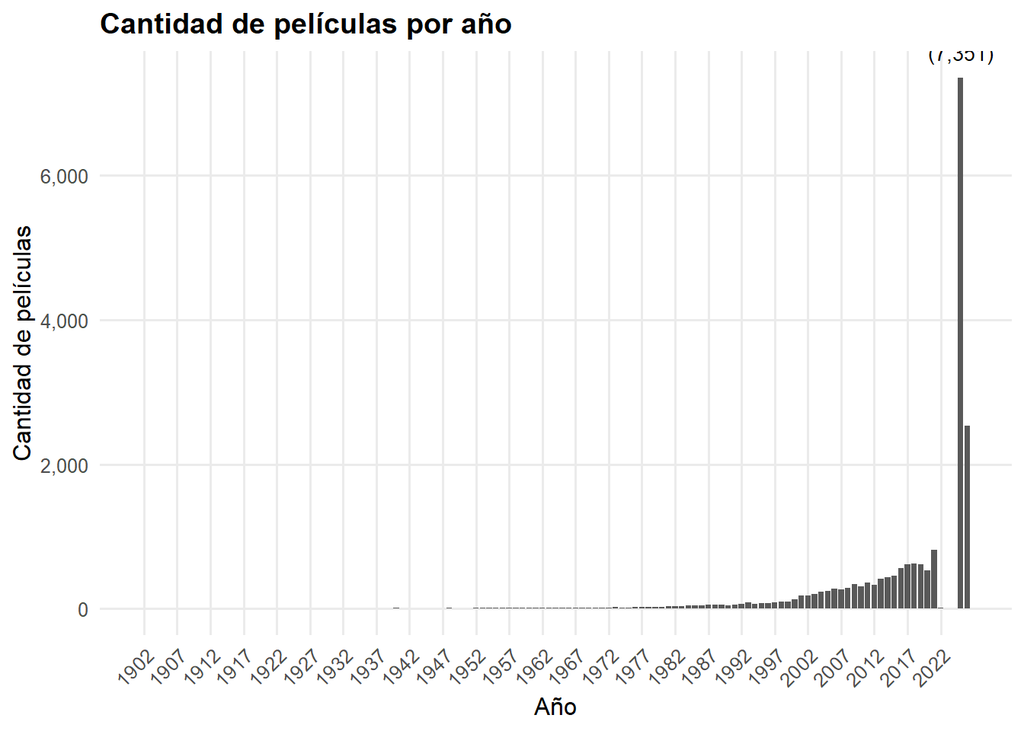

```r
peliculas_por_anio <- movies %>%
  filter(!is.na(releaseYear)) %>%
  mutate(releaseYear = as.integer(releaseYear)) %>%
  count(releaseYear, name = "cantidad") %>%
  arrange(releaseYear)

anio_mas <- peliculas_por_anio %>%
  slice_max(cantidad, n = 1, with_ties = FALSE)

ggplot(peliculas_por_anio, aes(x = releaseYear, y = cantidad)) +
  geom_col(width = 0.85) +
  geom_text(
    data = anio_mas,
    aes(label = paste0("Máximo: ", releaseYear, "\n(", comma(cantidad), ")")),
    vjust = -0.4,
    size = 3.5
  ) +
  scale_x_continuous(
    breaks = seq(min(peliculas_por_anio$releaseYear), max(peliculas_por_anio$releaseYear), by = 5)
  ) +
  scale_y_continuous(labels = comma) +
  labs(
    title = "Cantidad de películas por año",
    x = "Año",
    y = "Cantidad de películas"
  ) +
  theme_minimal(base_size = 12) +
  theme(
    panel.grid.minor = element_blank(),
    axis.text.x = element_text(angle = 45, hjust = 1),
    plot.title = element_text(face = "bold")
  )
```

###Género de películas

```r
movies2 <- movies %>%
  mutate(
    main_genre = ifelse(is.na(genres) | genres == "", "Sin género", sub("\\|.*", "", genres)),

    release_dt = suppressWarnings(ymd(releaseDate)),

    release_dt = ifelse(is.na(release_dt) & !is.na(releaseYear),
                        as.Date(paste0(releaseYear, "-12-31")),
                        release_dt) %>% as.Date()
  )
```

####top 20 películas más recientes

```r
top20_recientes <- movies2 %>%
  filter(!is.na(release_dt)) %>%
  arrange(desc(release_dt)) %>%
  select(title, releaseYear, releaseDate, main_genre, runtime) %>%
  head(20)

top20_recientes
```

```
##                                              title releaseYear releaseDate
## 1                                     A Fading Man        2026  2026-05-07
## 2        Elon Musk Unveiled – The Tesla Experiment        2026  2026-03-12
## 3                                            Skunk        2026  2026-02-25
## 4                                        Anastasia        2026  2026-02-25
## 5                                Nikki hako no koi        2026  2026-02-06
## 6                                         Immersed        2026  2026-02-01
## 7                                       Cinderella        2026  2026-02-01
## 8                                          Aladdin        2026  2026-02-01
## 9                            THE RING AND THE DECK        2026  2026-02-01
## 10                                  Crimson High 3        2026  2026-02-01
## 11 Conversations with Rasparagus Asparagus Baragus        2026  2026-02-01
## 12                                 Highway To Hell        2026  2026-02-01
## 13                                 Pari's daughter        2026  2026-02-01
## 14                                          Escort        2026  2026-02-01
```

[output cut: 27 more lines]

####Género predominante

```r
freq_genero <- movies2 %>%
  count(main_genre, sort = TRUE) %>%
  mutate(porcentaje = round(100*n/sum(n), 2))

freq_genero
```

```
##         main_genre    n porcentaje
## 1            Drama 3734      18.78
## 2           Comedy 2640      13.28
## 3      Documentary 2245      11.29
## 4       Sin género 1965       9.88
## 5           Action 1760       8.85
## 6           Horror 1513       7.61
## 7        Animation 1247       6.27
## 8         Thriller  854       4.30
## 9        Adventure  629       3.16
## 10         Romance  585       2.94
## 11           Crime  497       2.50
## 12          Family  469       2.36
## 13 Science Fiction  437       2.20
## 14           Music  373       1.88
## 15         Fantasy  364       1.83
## 16         Mystery  232       1.17
## 17             War   97       0.49
## 18        TV Movie   89       0.45
## 19         Western   87       0.44
## 20         History   66       0.33
```

####Género predominante

```r
genero_predominante <- freq_genero %>% head(1)
genero_predominante
```

```
##   main_genre    n porcentaje
## 1      Drama 3734      18.78
```

####Gráfico de top 15 géneros

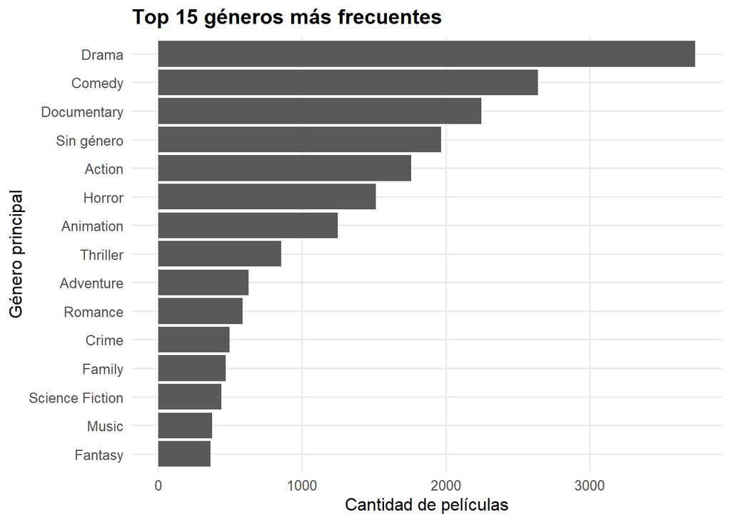

```r
freq_top15 <- freq_genero %>% head(15)

ggplot(freq_top15, aes(x = reorder(main_genre, n), y = n)) +
  geom_col() +
  coord_flip() +
  labs(
    title = "Top 15 géneros más frecuentes",
    x = "Género principal",
    y = "Cantidad de películas"
  ) +
  theme_minimal(base_size = 12) +
  theme(
    panel.grid.minor = element_blank(),
    plot.title = element_text(face = "bold")
  )
```

####Películas más largas

```r
top20_largas <- movies2 %>%
  filter(!is.na(runtime), runtime > 0) %>%
  arrange(desc(runtime)) %>%
  select(title, runtime, releaseYear, main_genre) %>%
  head(20)

top20_largas
```

```
##                                                             title runtime
## 1           How Ponyo was Born ~Hayao Miyazaki's Thought Process~     750
## 2                                                  Before the End     675
## 3                   League of Legends Worlds25 - Finals in Cinema     420
## 4  Crystal Lake Memories: The Complete History of Friday the 13th     400
## 5                                In Search of Darkness: 1995-1999     384
## 6                                    Vu 2025 (l’année du zapping)     366
## 7                                                        Napoleon     333
## 8                            White Gardenia: The King James Bible     330
## 9                                         NJPW Wrestle Kingdom 20     326
## 10                                                           1900     317
## 11                        The Idolm@ster Gakuen: Story of Re;IRIS     284
## 12                            Shpongle - Live at Mission Ballroom     263
## 13                                                     Indie Beat     261
## 14               2025 Rock & Roll Hall of Fame Induction Ceremony     261
```

[output cut: 27 more lines]

####Género de las películas más largas

```r
top50_largas <- movies2 %>%
  filter(!is.na(runtime), runtime > 0) %>%
  arrange(desc(runtime)) %>%
  head(50)

freq_genero_largas <- top50_largas %>%
  count(main_genre, sort = TRUE) %>%
  mutate(porcentaje = round(100*n/sum(n), 2))

freq_genero_largas
```

```
##     main_genre  n porcentaje
## 1       Action 12         24
## 2        Drama  8         16
## 3        Music  8         16
## 4   Sin género  8         16
## 5  Documentary  6         12
## 6       Comedy  3          6
## 7        Crime  2          4
## 8    Animation  1          2
## 9       Horror  1          2
## 10         War  1          2
```

####Género predominante en las más largas

```r
genero_top_largas <- freq_genero_largas %>% head(1)
genero_top_largas
```

```
##   main_genre  n porcentaje
## 1     Action 12         24
```

####Gráfico de los géneros predominantes en las películas más largas

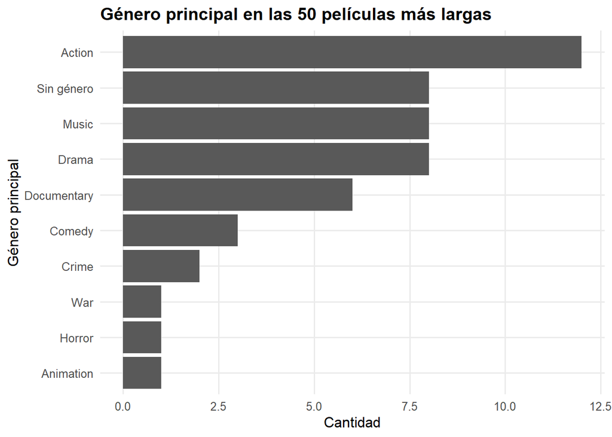

```r
ggplot(freq_genero_largas, aes(x = reorder(main_genre, n), y = n)) +
  geom_col() +
  coord_flip() +
  labs(
    title = "Género principal en las 50 películas más largas",
    x = "Género principal",
    y = "Cantidad"
  ) +
  theme_minimal(base_size = 12) +
  theme(
    panel.grid.minor = element_blank(),
    plot.title = element_text(face = "bold")
  )
```

####Género con más ganancias

```r
movies_gan <- movies %>%
  mutate(
    main_genre = ifelse(is.na(genres) | genres == "", "Sin género", sub("\\|.*", "", genres)),
    ganancia = revenue - budget
  ) %>%
  filter(!is.na(budget), !is.na(revenue), budget > 0, revenue > 0)

# Resumen por género
gan_por_genero <- movies_gan %>%
  group_by(main_genre) %>%
  summarise(
    peliculas = n(),
    ganancia_total = sum(ganancia, na.rm = TRUE),
    ganancia_promedio = mean(ganancia, na.rm = TRUE),
    ganancia_mediana = median(ganancia, na.rm = TRUE)
  ) %>%
  arrange(desc(ganancia_promedio))

gan_por_genero
```

```
## # A tibble: 19 × 5
##    main_genre      peliculas ganancia_total ganancia_promedio ganancia_mediana
##    <chr>               <int>          <dbl>             <dbl>            <dbl>
##  1 Animation             181    32005682028        176826973.        66053725
##  2 Adventure             351    60354070276        171948918.        57274484
##  3 Family                132    17978264869        136198976.        46970886.
##  4 Science Fiction       145    17757646253        122466526.        37106245
##  5 Action                779    92195613009        118351236.        34696996
##  6 Fantasy               137    15146197026        110556183.        43134790
##  7 War                    41     3379441894         82425412.        25641396
##  8 History                16     1077756790         67359799.        34837800.
##  9 Music                  35     2174083494         62116671.        10637469
## 10 Comedy                805    49220834911         61143894.        28780213
## 11 Romance               106     6325555484         59675052.        26764490.
## 12 Mystery                60     3378308280         56305138         17022368
## 13 Thriller              201    10151243101         50503697.        14171130
## 14 Drama                 860    42588500938         49521513.        14900000
## 15 Horror                373    18026440092         48328258.        22771059
## 16 Crime                 211     8254157389         39119229.        16282766
## 17 Western                34      928977440         27322866.         8648010
## 18 Sin género             16      258894806         16180925.               0
## 19 Documentary            19      247019250         13001013.             353
```

```r
genero_mayor_promedio <- gan_por_genero %>% head(1)
genero_mayor_promedio
```

```
## # A tibble: 1 × 5
##   main_genre peliculas ganancia_total ganancia_promedio ganancia_mediana
##   <chr>          <int>          <dbl>             <dbl>            <dbl>
## 1 Animation        181    32005682028        176826973.         66053725
```

```r
genero_mayor_total <- gan_por_genero %>%
  arrange(desc(ganancia_total)) %>%
  head(1)

genero_mayor_total
```

```
## # A tibble: 1 × 5
##   main_genre peliculas ganancia_total ganancia_promedio ganancia_mediana
##   <chr>          <int>          <dbl>             <dbl>            <dbl>
## 1 Action           779    92195613009        118351236.         34696996
```

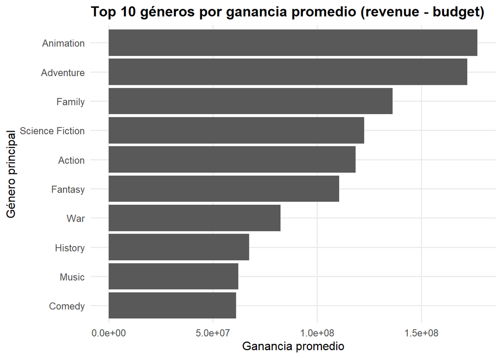

```r
library(ggplot2)

top10_gan <- gan_por_genero %>% head(10)

ggplot(top10_gan, aes(x = reorder(main_genre, ganancia_promedio), y = ganancia_promedio)) +
  geom_col() +
  coord_flip() +
  labs(
    title = "Top 10 géneros por ganancia promedio (revenue - budget)",
    x = "Género principal",
    y = "Ganancia promedio"
  ) +
  theme_minimal(base_size = 12) +
  theme(
    panel.grid.minor = element_blank(),
    plot.title = element_text(face = "bold")
  )
```

#### Análisis de actores

```r
##limpiar datos
df_actores_ing <- movies %>%
  filter(!is.na(actorsAmount), !is.na(revenue)) %>%
  filter(actorsAmount > 0, revenue > 0)

summary(df_actores_ing$actorsAmount)
```

```
##     Min.  1st Qu.   Median     Mean  3rd Qu.     Max.
##      1.0     19.0     29.0    264.5     46.0 668297.0
```

```r
summary(df_actores_ing$revenue)
```

```
##      Min.   1st Qu.    Median      Mean   3rd Qu.      Max.
## 1.000e+00 8.000e+06 3.863e+07 1.061e+08 1.175e+08 2.847e+09
```

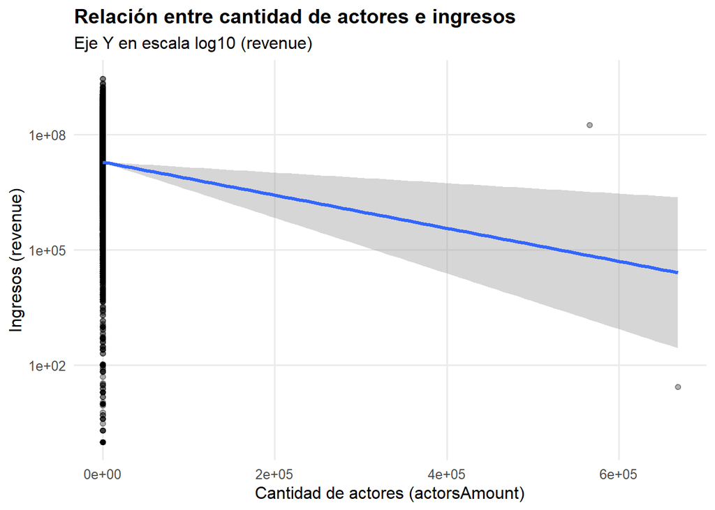

```r
##gráfico de relación entre cantidad de actores e ingresos
ggplot(df_actores_ing, aes(x = actorsAmount, y = revenue)) +
  geom_point(alpha = 0.3) +
  scale_y_log10() +
  geom_smooth(method = "lm", se = TRUE) +
  labs(
    title = "Relación entre cantidad de actores e ingresos",
    subtitle = "Eje Y en escala log10 (revenue)",
    x = "Cantidad de actores (actorsAmount)",
    y = "Ingresos (revenue)"
  ) +
  theme_minimal(base_size = 12) +
  theme(panel.grid.minor = element_blank(),
        plot.title = element_text(face = "bold"))
```

```r
##Actores por año
df_actores_anio <- movies %>%
  filter(!is.na(releaseYear), !is.na(actorsAmount)) %>%
  mutate(releaseYear = as.integer(releaseYear)) %>%
  filter(actorsAmount > 0)

actores_por_anio <- df_actores_anio %>%
  group_by(releaseYear) %>%
  summarise(
    peliculas = n(),
    promedio_actores = mean(actorsAmount, na.rm = TRUE),
    mediana_actores = median(actorsAmount, na.rm = TRUE)
  ) %>%
  arrange(releaseYear)

actores_por_anio
```

```
## # A tibble: 101 × 4
##    releaseYear peliculas promedio_actores mediana_actores
##          <int>     <int>            <dbl>           <dbl>
##  1        1902         1             11              11
##  2        1920         1             11              11
##  3        1921         1             35              35
##  4        1922         1             20              20
##  5        1925         2             31.5            31.5
##  6        1926         1             22              22
##  7        1927         2             41              41
##  8        1929         1              1               1
##  9        1930         1             44              44
## 10        1931         4             26              27.5
## # ℹ 91 more rows
```

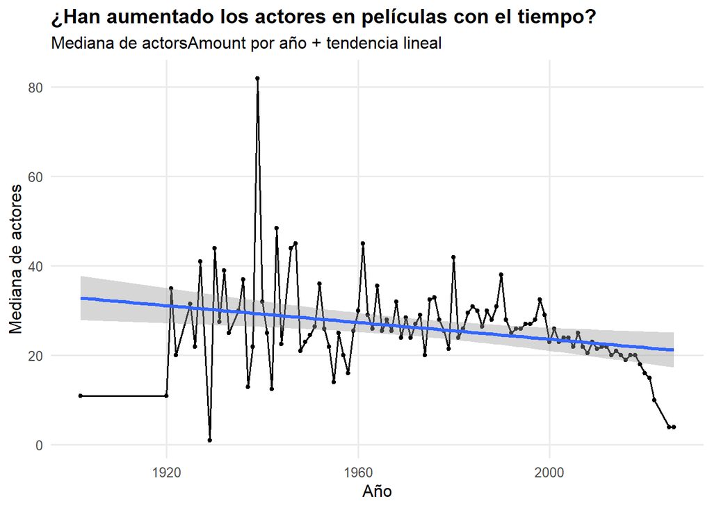

```r
##Gráfico de tendencia
ggplot(actores_por_anio, aes(x = releaseYear, y = mediana_actores)) +
  geom_line() +
  geom_point(size = 1) +
  geom_smooth(method = "lm", se = TRUE) +
  labs(
    title = "¿Han aumentado los actores en películas con el tiempo?",
    subtitle = "Mediana de actorsAmount por año + tendencia lineal",
    x = "Año",
    y = "Mediana de actores"
  ) +
  theme_minimal(base_size = 12) +
  theme(panel.grid.minor = element_blank(),
        plot.title = element_text(face = "bold"))
```

```r
##Comparación de los últimos años con años recientes
max_anio <- max(df_actores_anio$releaseYear, na.rm = TRUE)
corte <- max_anio - 5

comparacion <- df_actores_anio %>%
  mutate(periodo = ifelse(releaseYear >= corte, "Últimos 5 años", "Años anteriores")) %>%
  group_by(periodo) %>%
  summarise(
    peliculas = n(),
    promedio_actores = mean(actorsAmount, na.rm = TRUE),
    mediana_actores = median(actorsAmount, na.rm = TRUE)
  )

corte
```

```
## [1] 2021
```

```r
comparacion
```

```
## # A tibble: 2 × 4
##   periodo         peliculas promedio_actores mediana_actores
##   <chr>               <int>            <dbl>           <int>
## 1 Años anteriores      9087            2077.              22
## 2 Últimos 5 años       8155             324.               5
```

## 5. Análisis Exploratorio Adicional

En esta sección se plantean seis preguntas adicionales con el objetivo de explorar patrones complementarios en el conjunto de datos, sin repetir los análisis realizados en los incisos anteriores.

```r
movies_clean <- movies %>%
  filter(
    !is.na(revenue),
    !is.na(popularity),
    !is.na(runtime),
    !is.na(productionCountriesAmount),
    !is.na(genresAmount),
    !is.na(productionCoAmount),
    !is.na(castWomenAmount),
    !is.na(castMenAmount),
    !is.na(originalLanguage),
    !is.na(releaseYear)
  )
```

### 5.1 ¿Existe diferencia en los ingresos según la cantidad de países de producción?

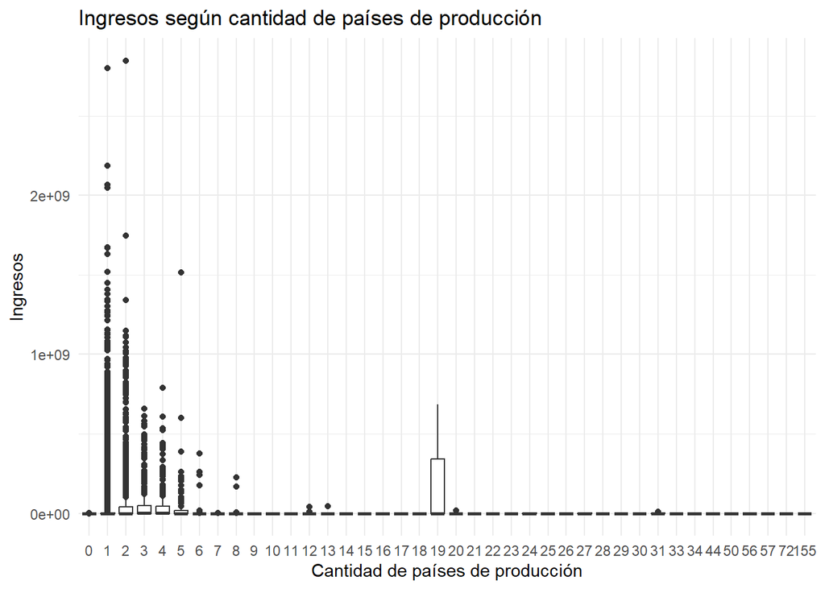

```r
ggplot(movies_clean, aes(x = factor(productionCountriesAmount), y = revenue)) +
  geom_boxplot() +
  labs(
    x = "Cantidad de países de producción",
    y = "Ingresos",
    title = "Ingresos según cantidad de países de producción"
  ) +
  theme_minimal()
```

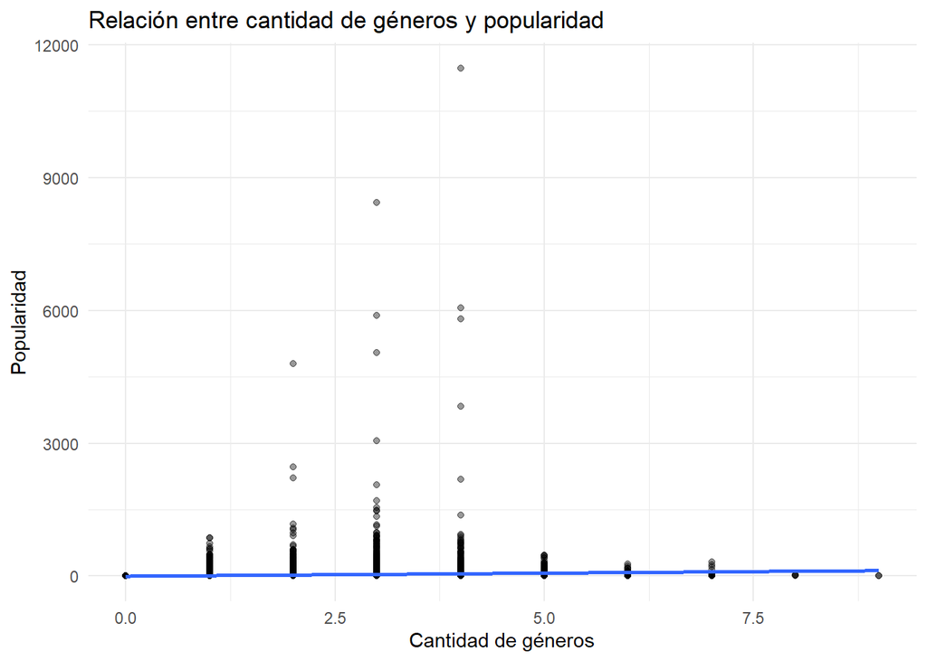

```r
ggplot(movies_clean, aes(x = genresAmount, y = popularity)) +
  geom_point(alpha = 0.4) +
  geom_smooth(method = "lm", se = FALSE) +
  labs(
    x = "Cantidad de géneros",
    y = "Popularidad",
    title = "Relación entre cantidad de géneros y popularidad"
  ) +
  theme_minimal()
```

### 5.3 ¿Cómo ha cambiado la duración promedio de las películas a lo largo del tiempo?

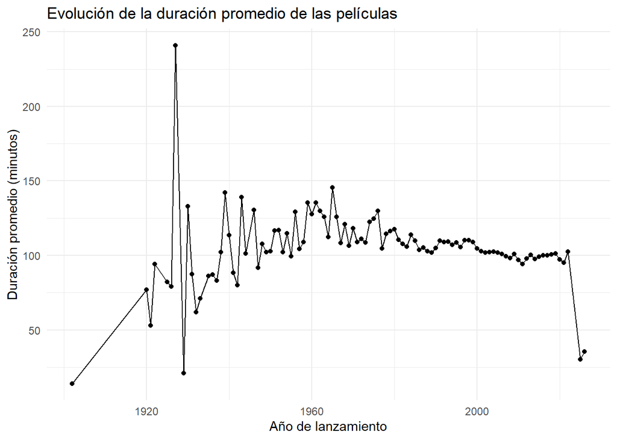

```r
runtime_year <- movies_clean %>%
  group_by(releaseYear) %>%
  summarise(runtime_promedio = mean(runtime))

ggplot(runtime_year, aes(x = releaseYear, y = runtime_promedio)) +
  geom_line() +
  geom_point() +
  labs(
    x = "Año de lanzamiento",
    y = "Duración promedio (minutos)",
    title = "Evolución de la duración promedio de las películas"
  ) +
  theme_minimal()
```

### 5.4 ¿Las películas con más compañías productoras generan mayores ingresos?

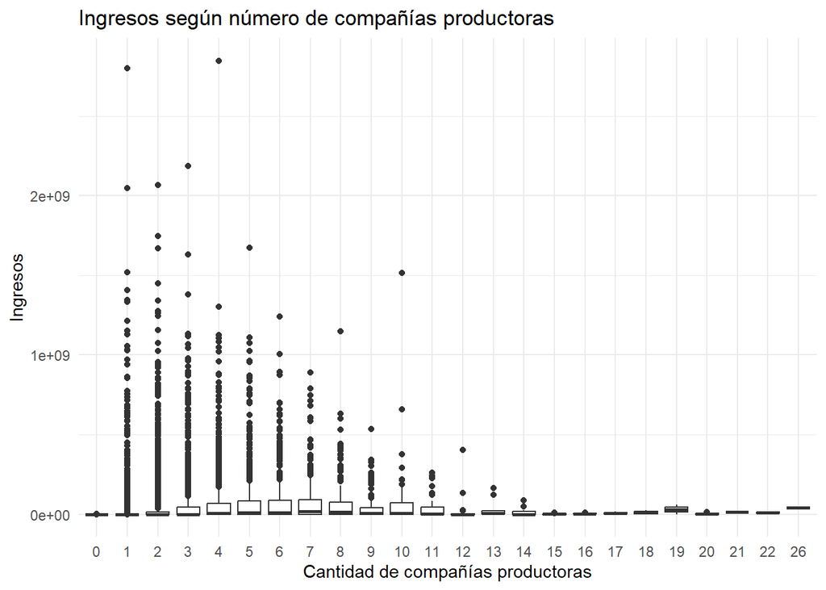

```r
ggplot(movies_clean, aes(x = factor(productionCoAmount), y = revenue)) +
  geom_boxplot() +
  labs(
    x = "Cantidad de compañías productoras",
    y = "Ingresos",
    title = "Ingresos según número de compañías productoras"
  ) +
  theme_minimal()
```

### 5.5 ¿Existen diferencias en la popularidad de las películas según su idioma original? En este análisis se consideran únicamente los idiomas más frecuentes en el conjunto de datos, con el fin de evitar sesgos causados por idiomas con muy pocas observaciones.

```r
# Seleccionar los 5 idiomas más frecuentes
top_languages <- movies_clean %>%
  group_by(originalLanguage) %>%
  summarise(n = n()) %>%
  arrange(desc(n)) %>%
  slice_head(n = 5)
```

```r
# Filtrar solo películas en esos idiomas
movies_lang <- movies_clean %>%
  filter(originalLanguage %in% top_languages$originalLanguage)
```

```r
# Calcular popularidad promedio por idioma
pop_lang <- movies_lang %>%
  group_by(originalLanguage) %>%
  summarise(popularidad_promedio = mean(popularity))
```

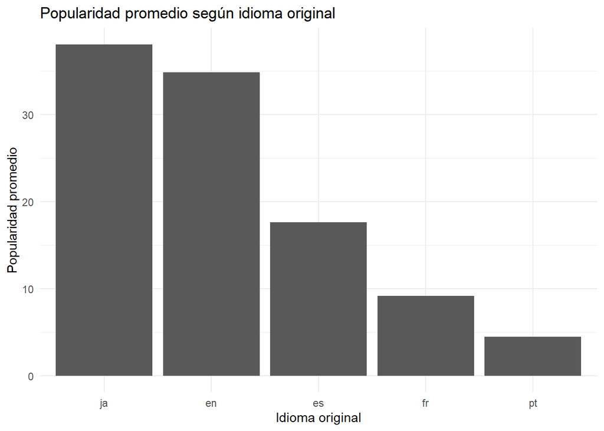

```r
# Gráfico de barras
ggplot(pop_lang, aes(
  x = reorder(originalLanguage, -popularidad_promedio),
  y = popularidad_promedio
)) +
  geom_col() +
  labs(
    x = "Idioma original",
    y = "Popularidad promedio",
    title = "Popularidad promedio según idioma original"
  ) +
  theme_minimal()
```

### 5.6 ¿El balance de género en el elenco influye en la popularidad de las películas?

```r
movies_gender <- movies_clean %>%
  mutate(ratio_genero = castWomenAmount / castMenAmount) %>%
  filter(is.finite(ratio_genero))
```

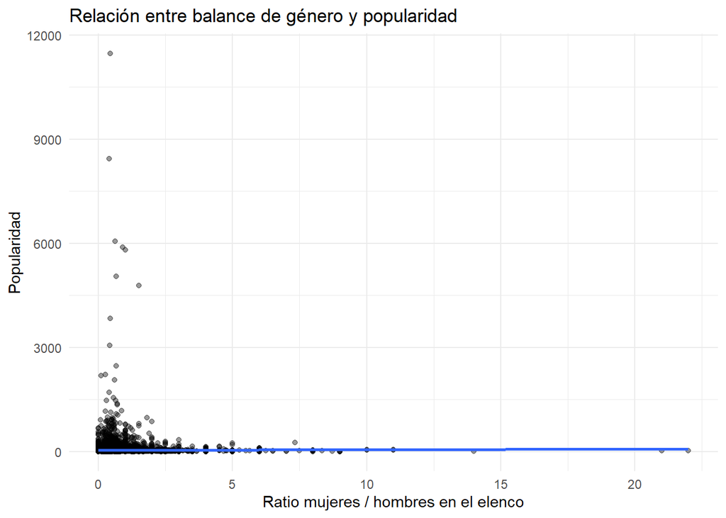

```r
ggplot(movies_gender, aes(x = ratio_genero, y = popularity)) +
  geom_point(alpha = 0.4) +
  geom_smooth(method = "lm", se = FALSE) +
  labs(
    x = "Ratio mujeres / hombres en el elenco",
    y = "Popularidad",
    title = "Relación entre balance de género y popularidad"
  ) +
  theme_minimal()
```